# Week 2. Introduction to R (III)

# 시각화 (Vizualization): `ggplot`

`ggplot2`에 내장되어 있는 `mpg`라는 데이터를 이용해서 시각화에 대한 간단한 내용을 살펴보도록 하겠습니다.

```r
library(ggplot2)
library(tidyverse)
df2 <- mpg
```

`cty`와 `hwy`는 각각 도시와 고속도로 주행에 있어서의 갤런 당 마일(mpg)을 기록한 변수입니다. `displ`은 리터 당 엔진의 배기량을 의미합니다. `drv`는 자동차의 변속기 종류를 보여줍니다: 전륜구동(front wheel, f), 후륜구동(rear wheel, r), 또는 사륜구동(four wheel, 4)로 나타냅니다. `model`은 자동차 모델명을 말합니다. 총 38개의 모델명이 있으며, 1999년부터 2008년 사이 매년마다 새로 출시된 모델들입니다. `class`는 차량 유형을 보여주는 분류형 변수입니다: 2인승, SUV, 콤팩트 등.

## 핵심적인 그래픽 요소들

모든 `ggplot2`로 그린 플롯은 3개의 주요 요소를 가집니다.

1. 먼저 너무나 당연하게도 플롯의 바탕이 되는 데이터입니다.
2. 둘째로 변수와 그래픽 속성 간의 관계를 나타내 주는 미학적 지도(aesthetic mappings)입니다.
3. 관측치를 보여줄 수 있는 최소한 하나 이상의 층위(레이어)가 필요합니다. 이러한 층위는 `geom_*`이라는 함수로 나타낼 수 있습니다.

## 간단한 예제

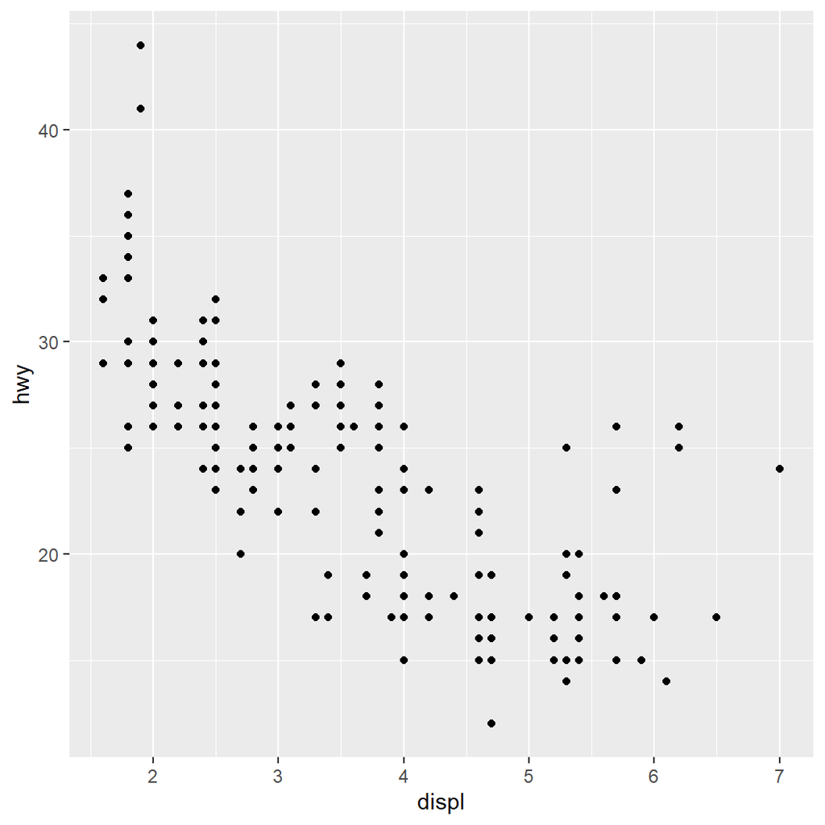

```r
ggplot(mpg,    # 우리가 그리고 싶은 데이터를 주고
  aes(x = displ, y = hwy)) +  # 어떤 변수들을 시각화하고 싶은지 지정합니다
  geom_point() # 점으로 기하학적 객체를 표현하라는 레이어를 덧붙입니다.
```

어떻게 데이터와 미학적 지도가 `ggplot()` 함수에 제공되는 지 눈치채셨나요? 그리고 앞의 함수를 살펴보면 추가적인 레이어가 `+`로 더해진 것을 확인할 수 있습니다. 그리고 미학적 지도는 항상 `aes()`의 함수 형태로 특정되는 것을 알 수 있습니다.

이 플롯에 변수를 몇 개 더 집어넣어보기 위해서는 `colour`, `shape`, 그리고 `size`와 같은 함수들을 이용할 수 있습니다. `ggplot2`의 몇몇 함수들은 영국식 스펠링을 가지고 있는데, 미국식 스펠링도 허용하니까 편하게 사용하면 됩니다. 추가적인 함수들도 `x`와 `y`라는 미학적 지도 함수를 사용했던 것과 동일하게 적용하면 됩니다. `aes()` 안에 집어넣으면 되는 것이죠.

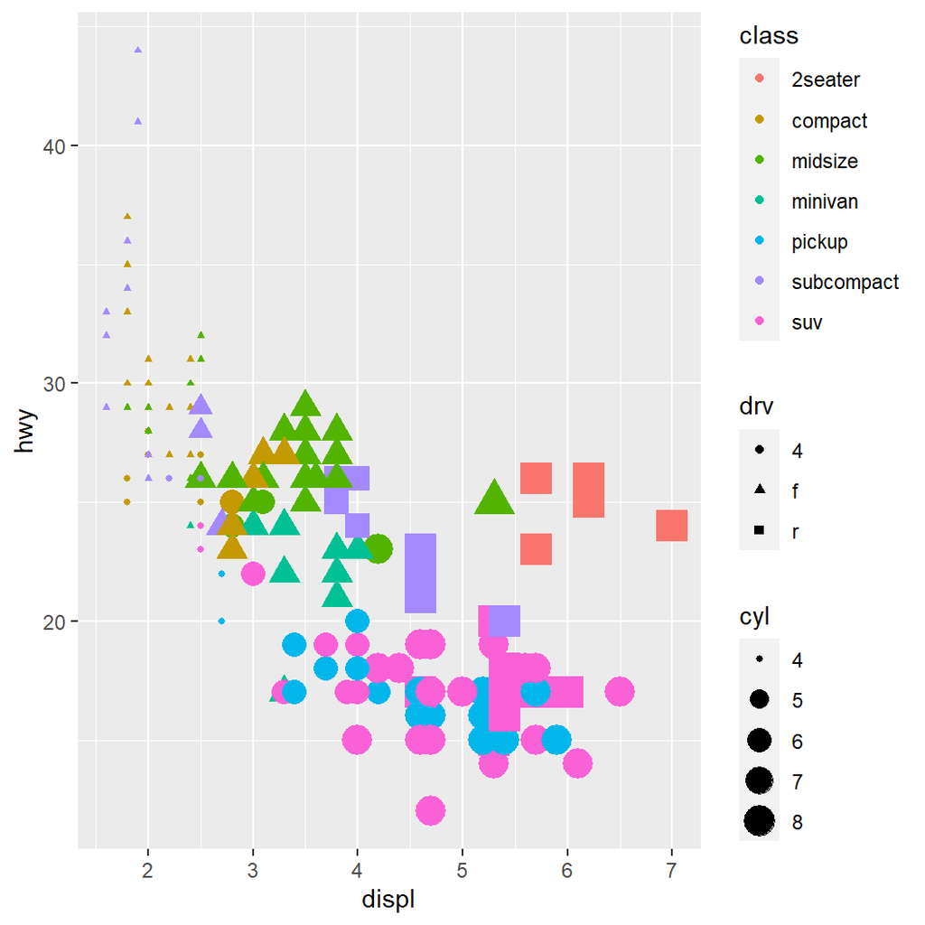

```r
ggplot(mpg, aes(displ, hwy, color = class, shape = drv, size = cyl)) +
  geom_point()
```

좀 더 익숙해지면 굳이 `aes()` 안에 `x`와 `y`를 지정해주지 않아도 됩니다. 왜냐면 맨 처음에 입력한 두 값은 자동으로 `x`와 `y`에 배정되기 때문입니다. 즉, `aes(x = displ, y = hwy)`나 `aes(displ, hwy)`나 동일합니다.

또한, `color`, `shape`, 그리고 `size`와 같은 추가적인 미학 함수들은 `aes()` 함수 내에서 특정되어야 합니다. 즉, `x`나 `y` 처럼 그냥 적으면 **R**이 알아먹지를 못합니다.

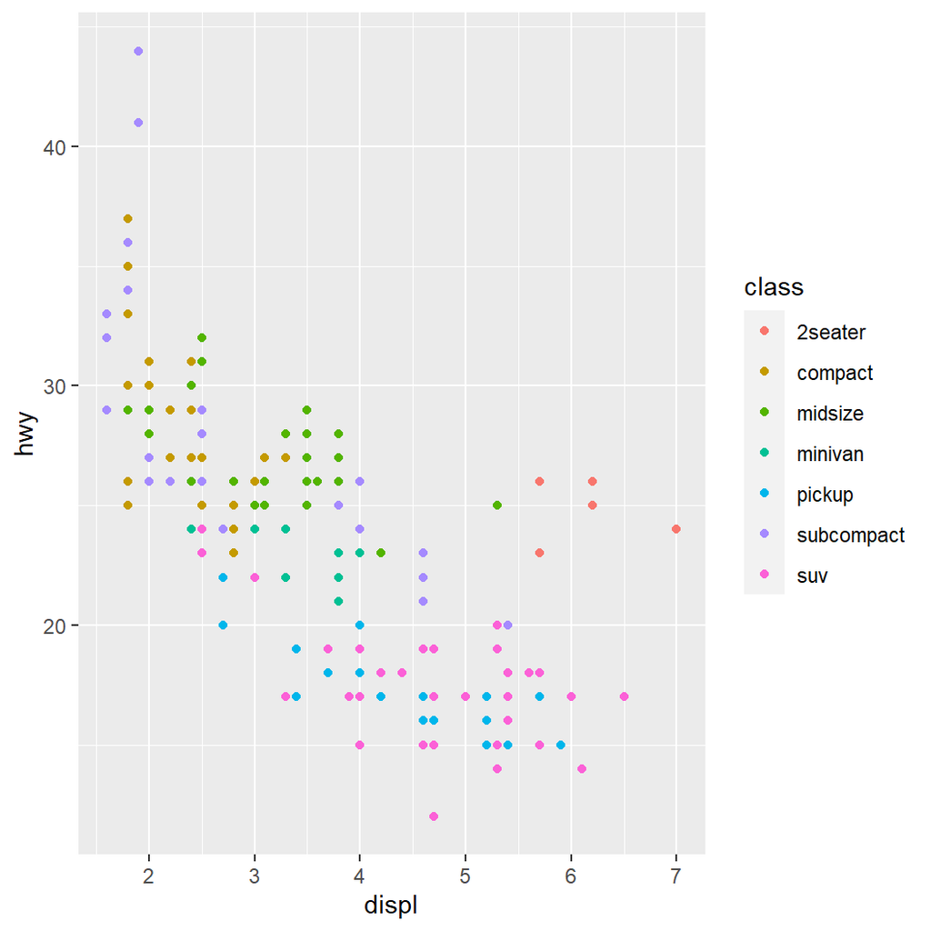

```r
ggplot(mpg, aes(displ, hwy, color = class)) +
  geom_point()
```

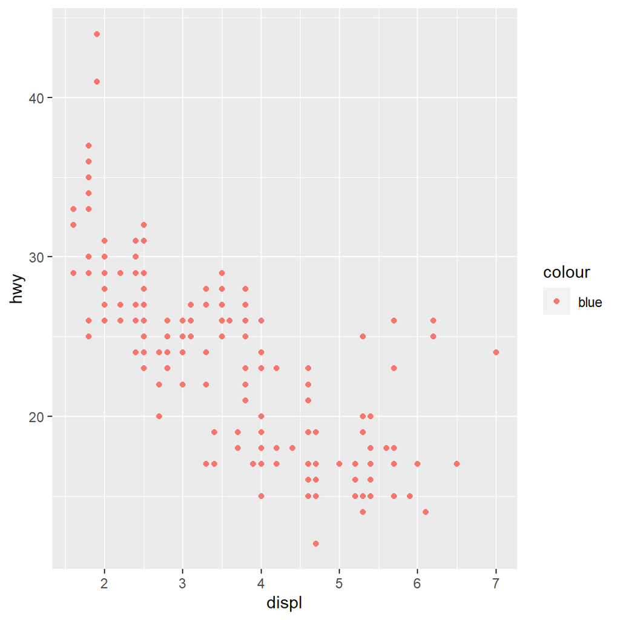

```r
ggplot(mpg, aes(displ, hwy)) + geom_point(aes(colour = "blue"))
```